# Lab 4

Hunter Finger

February 22, 2019

# Instructions

**Exercises:** 2,3 (Pg. 151); 2,4 (Pg. 156); 1,2 (Pgs. 160-161); 2 (Pg. 163); 2,3,4 (Pg. 168)

**Assigned:** Friday, February 15, 2019

**Due:** Friday, February 22, 2019 by 5:00 PM

**Submission:** Submit via an electronic document on Sakai. Must be submitted as a HTML file generated in RStudio. All assigned problems are chosen according to the textbook *R for Data Science*. You do not need R code to answer every question. If you answer without using R code, delete the code chunk. If the question requires R code, make sure you display R code. If the question requires a figure, make sure you display a figure. A lot of the questions can be answered in written response, but require R code and/or figures for understanding and explaining.

# Chapter 9 (Pg. 151)

## Exercise 2

```r
t2_cases <- filter(table2, type == "cases") %>% rename(cases = count) %>% arrange(country, year)
t2_popl <- filter(table2, type == "population") %>% rename(population = count) %>% arrange(country, year)
t2_case_per_capita = tibble(year = t2_cases$year, country = t2_cases$country, cases = t2_cases$cases, population = t2_popl$population) %>% mutate(cases_per_cap = (cases/population)*10000) %>% select(country, year, cases_per_cap, cases)

head(t2_case_per_capita)
```

```
## # A tibble: 6 x 4
##   country      year cases_per_cap  cases
##   <chr>       <int>         <dbl>  <int>
## 1 Afghanistan  1999         0.373    745
## 2 Afghanistan  2000         1.29    2666
## 3 Brazil       1999         2.19   37737
## 4 Brazil       2000         4.61   80488
## 5 China        1999         1.67  212258
## 6 China        2000         1.67  213766
```

```r
table4_combined = tibble(country = table4a$country, '1999' = table4a[["1999"]]/table4b[["1999"]] * 10000, '2000' = table4a[["2000"]]/table4b[["2000"]] * 10000)

head(table4_combined)
```

```
## # A tibble: 3 x 3
##   country     `1999` `2000`
##   <chr>        <dbl>  <dbl>
## 1 Afghanistan  0.373   1.29
## 2 Brazil       2.19    4.61
## 3 China        1.67    1.67
```

I thought that table 4 was easier to work with because it was easy to divide cases by population since they were in two sepatare tables. Table 2 took more work because I had to create two tables for cases and population and then combine them for cases per 10000 people.

## Exercise 3

First, we need to filter the table by cases. Then we plot the changes by year as shown below.

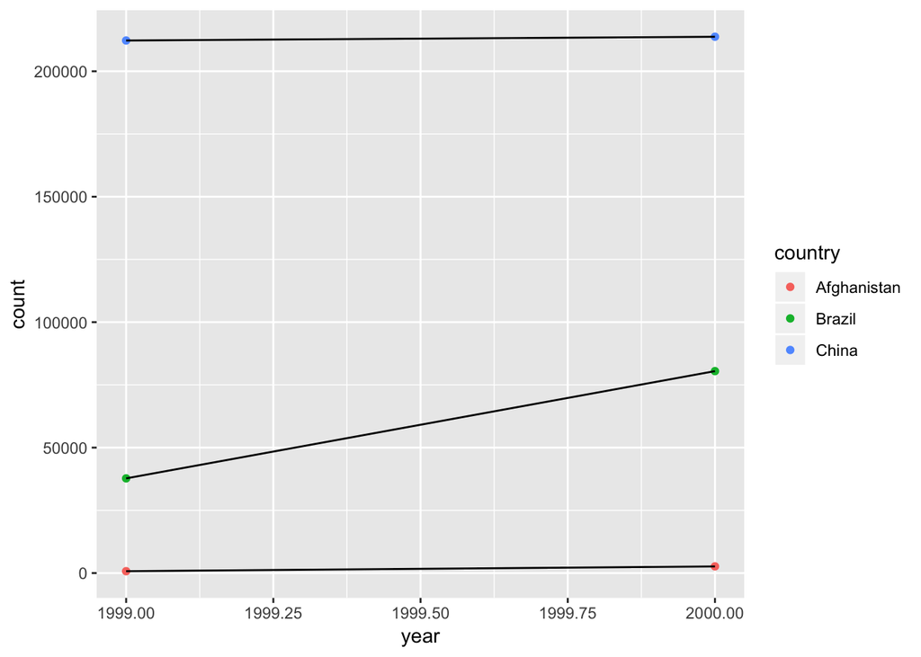

```r
table2 %>% filter(type == "cases") %>% ggplot(aes(year, count)) + geom_point(aes(color = country)) + geom_line(aes(group = country))
```

# Chapter 9 (Pg. 156)

## Exercise 2

table4a %>% gather(1999, 2000, key = “year”, value = “cases”)

Gather fails in this case because the values of 1999 and 2000 are read as the 1999th and 2000th column in the dataset. To fix this, we add ‘’ around the variable names.

```r
table4a %>%
  gather('1999', '2000', key = "year", value = "cases")
```

```
## # A tibble: 6 x 3
##   country     year   cases
##   <chr>       <chr>  <int>
## 1 Afghanistan 1999     745
## 2 Brazil      1999   37737
## 3 China       1999  212258
## 4 Afghanistan 2000    2666
## 5 Brazil      2000   80488
## 6 China       2000  213766
```

## Exercise 4

```r
preg <- tribble(
~pregnant, ~male, ~female, "yes", NA, 10, "no", 20, 12
)

preg_clean <- preg %>% gather(male, female, key = "gender", value = "count")

head(preg_clean)
```

```
## # A tibble: 4 x 3
##   pregnant gender count
##   <chr>    <chr>  <dbl>
## 1 yes      male      NA
## 2 no       male      20
## 3 yes      female    10
## 4 no       female    12
```

The data set needs to be gathered. The variables are gender, count, and pregnant.

# Chapter 9 (Pgs. 160-161)

## Exercise 1

```r
tibble(x = c("a,b,c", "d,e,f,g", "h,i,j")) %>%
      separate(x, c("one", "two", "three"))
```

```
## # A tibble: 3 x 3
##   one   two   three
##   <chr> <chr> <chr>
## 1 a     b     c
## 2 d     e     f
## 3 h     i     j
```

```r
tibble(x = c("a,b,c", "d,e,f,g", "h,i,j")) %>%
      separate(x, c("one", "two", "three"), extra = "drop")
```

```
## # A tibble: 3 x 3
##   one   two   three
##   <chr> <chr> <chr>
## 1 a     b     c
## 2 d     e     f
## 3 h     i     j
```

```r
tibble(x = c("a,b,c", "d,e", "f,g,i")) %>%
      separate(x, c("one", "two", "three"))
```

```
## # A tibble: 3 x 3
##   one   two   three
##   <chr> <chr> <chr>
## 1 a     b     c
## 2 d     e     <NA>
## 3 f     g     i
```

```r
tibble(x = c("a,b,c", "d,e", "f,g,i")) %>%
      separate(x, c("one", "two", "three"), fill = "left")
```

```
## # A tibble: 3 x 3
##   one   two   three
##   <chr> <chr> <chr>
## 1 a     b     c
## 2 <NA>  d     e
## 3 f     g     i
```

The **fill** argument tells the dataset how to fill the data if you have too few data. In the 3rd tibble, the second group is short 1 piece of data resulting in the NA value being on the right. When I set fill to left, the NA value is now places at the beginning of the set of values.

The **extra** argument tells the separate what to do with extra values. In the first tibble, the 2nd group has too many values and the resulting table shows a warning. By setting extra to drop, the same thing happens, but without the warning.

## Exercise 2

```r
table3 %>%
    separate(rate, into = c("cases", "population"), remove = TRUE)
```

```
## # A tibble: 6 x 4
##   country      year cases  population
##   <chr>       <int> <chr>  <chr>
## 1 Afghanistan  1999 745    19987071
## 2 Afghanistan  2000 2666   20595360
## 3 Brazil       1999 37737  172006362
## 4 Brazil       2000 80488  174504898
## 5 China        1999 212258 1272915272
## 6 China        2000 213766 1280428583
```

```r
table3 %>%
    separate(rate, into = c("cases", "population"), remove = FALSE)
```

```
## # A tibble: 6 x 5
##   country      year rate              cases  population
##   <chr>       <int> <chr>             <chr>  <chr>
## 1 Afghanistan  1999 745/19987071      745    19987071
## 2 Afghanistan  2000 2666/20595360     2666   20595360
## 3 Brazil       1999 37737/172006362   37737  172006362
## 4 Brazil       2000 80488/174504898   80488  174504898
## 5 China        1999 212258/1272915272 212258 1272915272
## 6 China        2000 213766/1280428583 213766 1280428583
```

The remove argument is used to discard the old input columns. The reasoning for it being false would be if you wanted to create a new variable with the old one.

# Chapter 9 (Pg. 163)

## Exercise 2

```r
treatment <- tribble(
~ person, ~ treatment, ~response, "Derrick Whitmore", 1, 7,
NA, 2, 10,
NA, 3, 9, "Katherine Burke", 1, 4
)

treatment %>%
      fill(person, .direction = "down")
```

```
## # A tibble: 4 x 3
##   person           treatment response
##   <chr>                <dbl>    <dbl>
## 1 Derrick Whitmore         1        7
## 2 Derrick Whitmore         2       10
## 3 Derrick Whitmore         3        9
## 4 Katherine Burke          1        4
```

```r
treatment %>%
      fill(person, .direction = "up")
```

```
## # A tibble: 4 x 3
##   person           treatment response
##   <chr>                <dbl>    <dbl>
## 1 Derrick Whitmore         1        7
## 2 Katherine Burke          2       10
## 3 Katherine Burke          3        9
## 4 Katherine Burke          1        4
```

The **direction** tells fill whether to fill the NA values top down (down) or bottom up (up).

# Chapter 9 (Pg. 168)

## Exercise 2

```r
who %>%
gather(code, value, new_sp_m014:newrel_f65, na.rm = TRUE) %>% mutate(
        code = stringr::str_replace(code, "newrel", "new_rel")
      ) %>%
      separate(code, c("new", "var", "sexage")) %>%
      select(-new, -iso2, -iso3) %>%
      separate(sexage, c("sex", "age"), sep = 1)
```

```
## # A tibble: 76,046 x 6
##    country      year var   sex   age   value
##    <chr>       <int> <chr> <chr> <chr> <int>
##  1 Afghanistan  1997 sp    m     014       0
##  2 Afghanistan  1998 sp    m     014      30
##  3 Afghanistan  1999 sp    m     014       8
##  4 Afghanistan  2000 sp    m     014      52
##  5 Afghanistan  2001 sp    m     014     129
##  6 Afghanistan  2002 sp    m     014      90
##  7 Afghanistan  2003 sp    m     014     127
##  8 Afghanistan  2004 sp    m     014     139
##  9 Afghanistan  2005 sp    m     014     151
## 10 Afghanistan  2006 sp    m     014     193
## # … with 76,036 more rows
```

```r
who %>%
gather(code, value, new_sp_m014:newrel_f65, na.rm = TRUE) %>%
      separate(code, c("new", "var", "sexage")) %>%
      select(-new, -iso2, -iso3) %>%
      separate(sexage, c("sex", "age"), sep = 1)
```

```
## # A tibble: 76,046 x 6
##    country      year var   sex   age   value
##    <chr>       <int> <chr> <chr> <chr> <int>
##  1 Afghanistan  1997 sp    m     014       0
##  2 Afghanistan  1998 sp    m     014      30
##  3 Afghanistan  1999 sp    m     014       8
##  4 Afghanistan  2000 sp    m     014      52
##  5 Afghanistan  2001 sp    m     014     129
##  6 Afghanistan  2002 sp    m     014      90
##  7 Afghanistan  2003 sp    m     014     127
##  8 Afghanistan  2004 sp    m     014     139
##  9 Afghanistan  2005 sp    m     014     151
## 10 Afghanistan  2006 sp    m     014     193
## # … with 76,036 more rows
```

The mutate step fills in the values for the missing information in the lower rows in the dataset.

## Exercise 3

```r
select(who, country, iso2, iso3) %>% distinct() %>% group_by(country) %>% filter(n() > 1)
```

```
## # A tibble: 0 x 3
## # Groups:   country [0]
## # … with 3 variables: country <chr>, iso2 <chr>, iso3 <chr>
```

All the codes are differing by just 1 because the iso3 just adds a character to the iso2 code.

## Exercise 4

```r
who_visual = who %>%
gather(code, value, new_sp_m014:newrel_f65, na.rm = TRUE) %>% mutate(
        code = stringr::str_replace(code, "newrel", "new_rel")
      ) %>%
      separate(code, c("new", "var", "sexage")) %>%
      select(-new, -iso2, -iso3) %>%
      separate(sexage, c("sex", "age"), sep = 1)

head(who_visual)
```

```
## # A tibble: 6 x 6
##   country      year var   sex   age   value
##   <chr>       <int> <chr> <chr> <chr> <int>
## 1 Afghanistan  1997 sp    m     014       0
## 2 Afghanistan  1998 sp    m     014      30
## 3 Afghanistan  1999 sp    m     014       8
## 4 Afghanistan  2000 sp    m     014      52
## 5 Afghanistan  2001 sp    m     014     129
## 6 Afghanistan  2002 sp    m     014      90
```

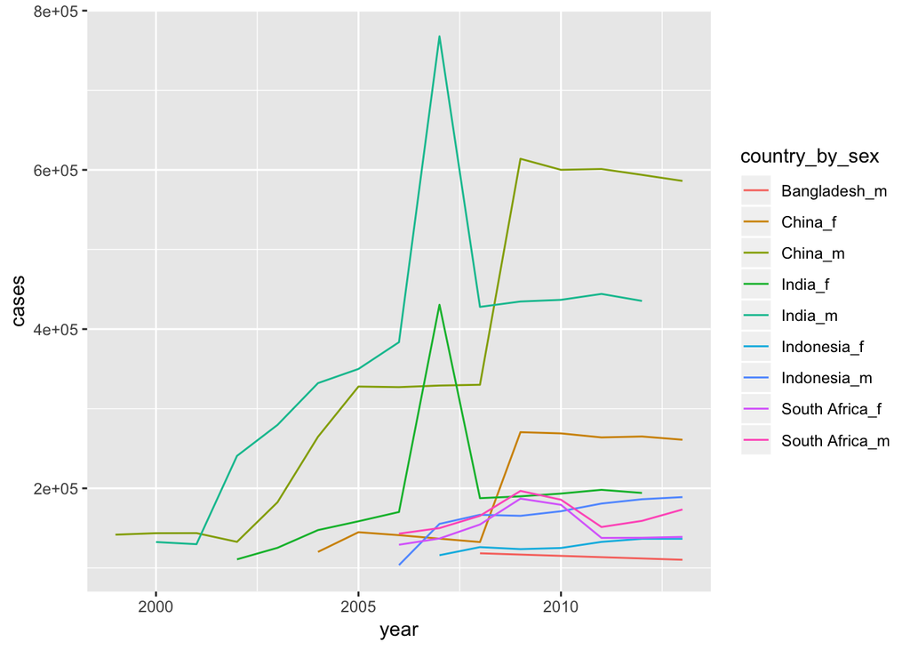

```r
who_visual %>% group_by(country, year, sex) %>% filter(year > 1998) %>% summarize(cases = sum(value)) %>% unite(country_by_sex, country, sex, remove = FALSE) %>% filter(cases > 100000) %>% ggplot(aes(x = year, y = cases, color = country_by_sex)) +
  geom_line()
```

Above is all the counties with more than 100000 cases per sex. I filtered to this becuase otherwise there were many countries in the data set and it looked cluttered, so I focused on the countries with the most cases.